# Section 9: Model Diagnostics for Mixed-Effects Models

Keith Lohse, PhD, PStat

2026-11-20

We have spent eight sections building progressively more sophisticated mixed-effects models, but we have not yet stopped to systematically ask: how do we know a model is any good? A model can converge, produce a tidy `summary()` table, and still be badly misspecified. This section works through a practical diagnostic checklist, and the specific plots used to carry each check out. Our focus here is deliberately narrow: this is about diagnostic visualization – plots whose job is to help you decide whether a model is trustworthy – not about general data visualization or building a polished figure to communicate a result to a reader. For guidance on the latter, a dedicated data-visualization reference is a better resource than this section.

## 9.1. What Are We Actually Checking?

Linear mixed-effects models rest on several distributional assumptions, extending the familiar ones from ordinary regression:

1. **Additivity and Linearity**: I would more generally phrase this as the “shape” of our relationship correct. That is, we can fit curvilinear regressions with polynomials but remember that polynomials are additive and linear in their components (e.g., `time + I(time^2)`). Bottom line, if we fit linear `time` to a non-linear pattern, everything downstream from that is likely biased.
2. **Normality of residuals**: $\epsilon_{ij} \sim \mathcal{N}(0, \sigma^2)$.
3. **Normality of random effects**: $\mathbf{b}_i \sim \mathcal{N}(\mathbf{0}, \boldsymbol{\Sigma}_b)$. The random slopes and intercepts, not just the residuals, should also look roughly normal.
4. **Homoscedasticity**: residual variance is roughly constant across the range of fitted values and predictors (Section 6 covered what to do when this fails outright).

And then we have two important *considerations* (not strictly speaking assumptions) that we want to check: 5. **No excessive collinearity** among the fixed-effect predictors, which inflates standard errors and makes individual coefficients unstable even when the overall model fits well. 6. **No single subject/cluster with disproportionate influence** on the fixed-effect estimates.

We’ll fit one example model and then work through each of these in turn.

```r
library(tidyverse)
library(lme4)
library(lmerTest)
```

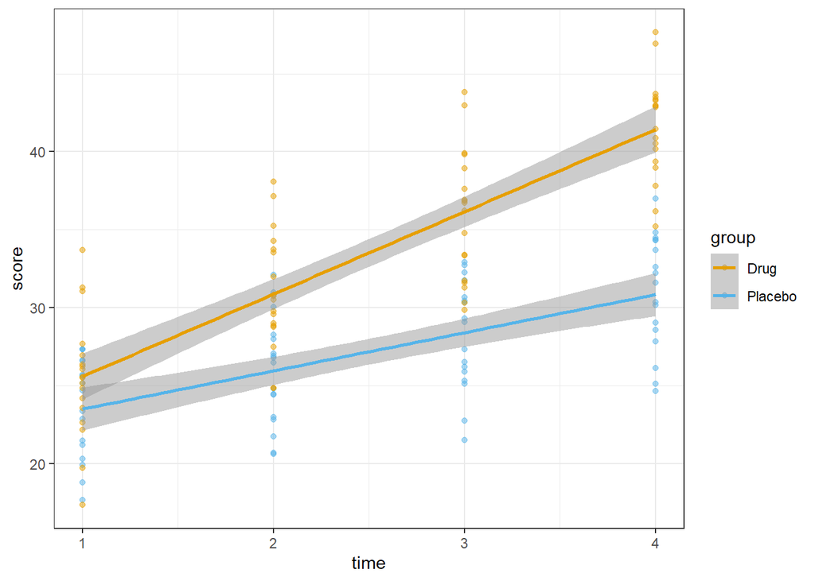

```r
set.seed(456)
n_sub <- 35
df_diag <- expand.grid(
  subID = factor(1:n_sub),
  time  = 1:4
) %>%
  mutate(
    # As in Section 7, note that group is assigned by SUBJECT (as.numeric(subID)),
    # not by row order, so that it is a genuine between-subjects grouping factor.
    group = factor(if_else(as.numeric(subID) <= n_sub / 2, "Placebo", "Drug")),
    score = 20 + 2.5 * time + 3.0 * (group == "Drug") * time +
      rnorm(n_sub, 0, 3)[subID] + rnorm(n(), 0, 1.5)
  )

ggplot(data=df_diag, aes(x=time, y=score))+
  geom_point(aes(col=group), alpha=0.5)+
  stat_smooth(aes(col=group), alpha=0.5, method="lm")+
  theme_bw() +
  scale_color_manual(values=c("#E69F00", "#56B4E9"))
```

```r
mod_diag <- lmer(score ~ group * time + (1 + time | subID), data = df_diag)
anova(mod_diag)
```

|  | Sum Sq | Mean Sq | NumDF | DenDF | F value | Pr(>F) |
| --- | --- | --- | --- | --- | --- | --- |
| group | 0.4901758 | 0.4901758 | 1 | 32.99990 | 0.3038017 | 5.852218e-01 |
| time | 1497.4839611 | 1497.4839611 | 1 | 32.99953 | 928.1122324 | 9.693822e-26 |
| group:time | 201.1759476 | 201.1759476 | 1 | 32.99953 | 124.6850468 | 9.531721e-13 |

## 2. Adding Our Residuals and Fitted Values into the Data Frame

To perform many of our diagnostic checks, it is helpful to add the fitted values and residuals from our model back into the data. **Note the simplest tools for doing this `resid()` and `fitted()` export a vector equal in length to the number of observations that went into the model.** In practice, this means you need to be careful about any cases with missing values that might have been dropped from the model. Usually, you will just get an error that the data frame and the vector are not the same length and cannot be added together but it is good to remember that these functions do not automatically know which observations go with which participant are time point, so you - as the user - need to make sure the rows are lining up correctly.

As a reminder, from a mixed model, we will get residuals and two different kinds of fitted values:

- Marginal Fitted Values: Use only the models fixed effects and ignore random effects (e.g., two participants from the group with have the same marginal fitted values if Group was a fixed effect).
- Conditional Fitted Values: Use both the fixed effects and random effects to get a unique estimated value for each participants (e.g., two participants from the same group will have different conditional fitted values because conditional fitted values add their fixed and random effects together to get unique estimates for each person).
- Residuals: Residuals are the differences between our data - the actual observed values - and the fitted values. Typically, we are interested in the **conditional residuals** (i.e., the difference between the data and each unique estimate) but we can also calculate **marginal residuals** (i.e., the difference between the data and the fixed effects only).

```r
# ---- Add fitted values and residuals to the data ----------------------------
# lmer gives two kinds of fitted values and residuals:
#   * Conditional: use the fixed effects AND the subject's own random effects
#       fitted = X*b + Z*u ;  residual = y - X*b - Z*u   (level-1 residuals)
#   * Marginal: use the fixed effects only
#       fitted = X*b       ;  residual = y - X*b         (subject deviations + noise)
# The level-1 assumptions (constant variance, normality) are about the
# CONDITIONAL residuals. Marginal residuals are useful for checking whether
# the population-average trajectory is right.
df_diag <- df_diag %>%
  mutate(
    fit_cond   = fitted(mod_diag),                # X*b + Z*u
    res_cond   = resid(mod_diag),                 # y - (X*b + Z*u)
    fit_marg   = predict(mod_diag, re.form = NA), # X*b only
    res_marg   = score - fit_marg,
    # Standardized conditional residuals: residual / sigma
    res_std    = res_cond / sigma(mod_diag)
  )
```

## 2. Do we have the “shape” of the data correct?

Using these fitted values and residuals, we can do several checks to make sure we have the “shape” of the data correct.

**First, we can create a residuals versus fitted values plot** in which we plot the conditional residuals on the y-axis against the conditional fitted values on the x-axis. If we have the shape of the relationship (alternatively “functional form”) correct, then there should be no real pattern to the residuals. If we see a clear pattern in the residuals (e.g., U-shape or n-shape) that would suggest there is some non-linearity in the data we are not accounting for (e.g., we fit linear function for `time` and instead should fit a quadratic, `time+I(time^2)`.

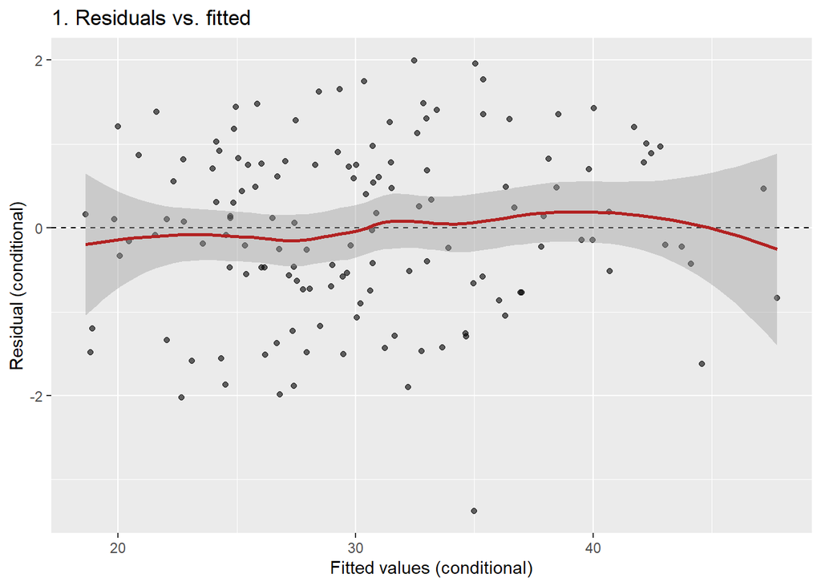

```r
# 1. Residuals vs. fitted values ----------------------------------------------
# We want a flat, patternless band centered on zero. A curve (U shape or
# arch) suggests a wrong functional form, such as a missing quadratic term.
p_res_fit <- ggplot(df_diag, aes(x = fit_cond, y = res_cond)) +
  geom_hline(yintercept = 0, linetype = "dashed") +
  geom_point(alpha = 0.6) +
  geom_smooth(method = "loess", formula = y ~ x, se = TRUE, colour = "firebrick") +
  labs(title = "1. Residuals vs. fitted",
       x = "Fitted values (conditional)", y = "Residual (conditional)")
p_res_fit
```

The residuals versus fitted plot combines the contributions of all fixed and random effects into a single fitted value. That makes it a convenient overall check, especially for whether residual variance changes with the predicted mean. But collapsing everything onto one axis can also hide problems: a misspecified effect of one predictor can be diluted or cancelled by the others. Plotting residuals against each predictor separately is a more sensitive check of functional form, and plotting them against one predictor within levels of another (here, `time` within `group`) checks additivity.

Note that our assumptions about shape really only applies to the continuous predictor and it’s interactions (e.g., for a categorical factor, we will estimate a unique mean for every level, so we cannot really get the shape of it’s mean structure wrong). When we shift to just `time` as a specific predictor, we will also switch to the marginal residuals. Using conditional residuals here wouldn’t be wrong, but it could mislead: the subject-level random effects can absorb some misspecification and make it look as though we’ve captured the shape of `time` better than we have. Broadly, marginal residuals are the natural choice for checking the fixed part of the model, and conditional residuals for checking the error assumptions at the lowest level of the data.

In the plot below, we are interested in a few things. First, is the mean of the residuals generally close to zero across time? This suggests we got the shape of time correct. Second, do we see a similar pattern in the mean of the residuals in both groups? This suggests the same shape of time applies to both groups. And third, do we see any difference in the **variance** of the residuals across time? This is our first check into the **heteroskedasticity** of the residuals.

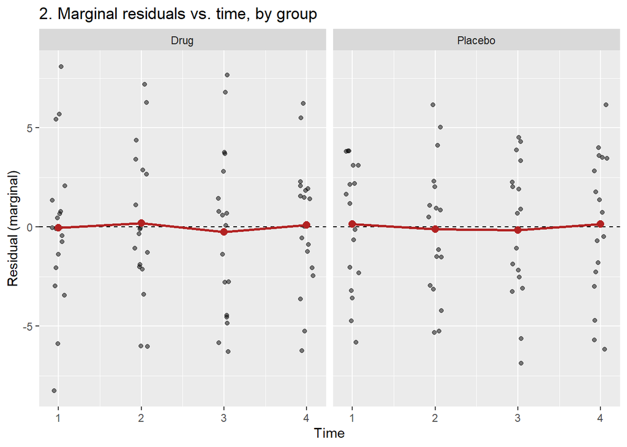

```r
# 2. Residuals vs. predictors -------------------------------------------------
# Same idea, but against each predictor, here time separately by group.
# Using the MARGINAL residuals asks: "Does the population-average line for each
# group follow the data at every time point?" Mean marginal residuals that
# drift away from 0 at certain times mean the trajectory shape is wrong.
p_res_time <- ggplot(df_diag, aes(x = time, y = res_marg)) +
  geom_hline(yintercept = 0, linetype = "dashed") +
  geom_jitter(width = 0.08, alpha = 0.5) +
  stat_summary(fun = mean, geom = "line", colour = "firebrick", linewidth = 1) +
  stat_summary(fun = mean, geom = "point", colour = "firebrick", size = 2.5) +
  facet_wrap(~ group) +
  labs(title = "2. Marginal residuals vs. time, by group",
       x = "Time", y = "Residual (marginal)")
p_res_time
```

Finally, it helps to plot the observed trajectories (a spaghetti plot of each participant’s data over `time`) against the trajectories implied by the model (the group-average lines from our fixed effects). This plot asks two questions. First, does the model’s average trajectory match the overall shape of the data? Second, do the individual trajectories vary in ways the model can represent?

Suppose most participants follow a roughly linear path and the model estimates a linear trend: good agreement. But suppose many participants level off or tail downward at later time points. Then the average trajectory isn’t linear, and the fixed effect of time is misspecified; we may need a quadratic or spline term. The same is true if the curvature shows up in one group but not the other: the model is missing a group-by-curvature interaction.

If we have tested a series of unconditional models on the front-end, this can often be a more confirmatory step (e.g., linear slopes led to the lowest AIC and we see agreement in linear slopes). However, because we often choose the shape of `time` in unconditional models on the front-end, we can now check that it still accurately reflects each group on the back-end once all moderators are accounted for.

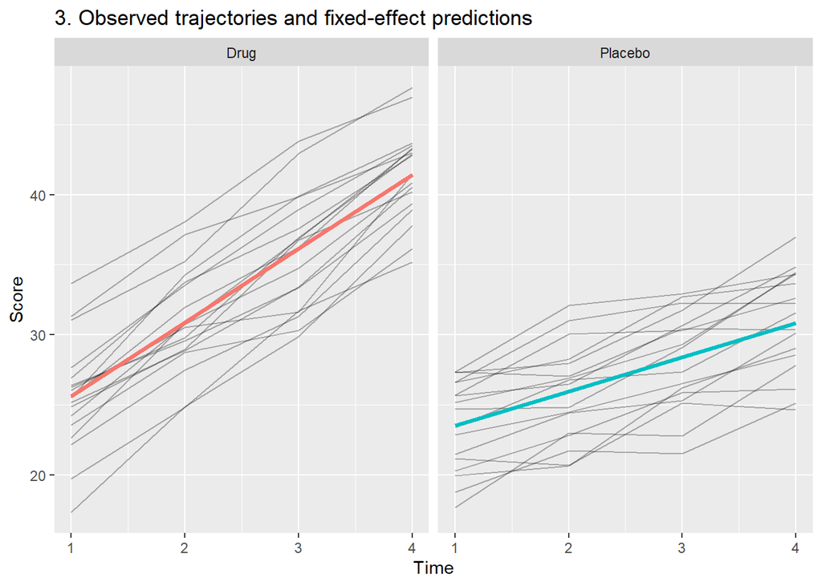

```r
# 3. Observed vs. model-implied trajectories ----------------------------------
# Thin lines show each subject's observed data. Thick lines show the
# fixed-effect (population-average) prediction for each group. Model and data
# should follow the same overall shape.
p_traj <- ggplot(df_diag, aes(x = time, y = score)) +
  geom_line(aes(group = subID), alpha = 0.3) +
  geom_line(aes(y = fit_marg, colour = group), linewidth = 1.3) +
  facet_wrap(~ group) +
  labs(title = "3. Observed trajectories and fixed-effect predictions",
       x = "Time", y = "Score") +
  theme(legend.position = "none")

p_traj
```

## 3. Assumptions about the Random Parts of the Model

Additionally, we can plot our conditional residuals at the specific levels of our fixed effects, by `group` in this case. If one group showed massively larger residual variance than the other group, that would suggest we need a more complicated model (i.e., at present our model assumes that a single residual variance applies equally to both groups).

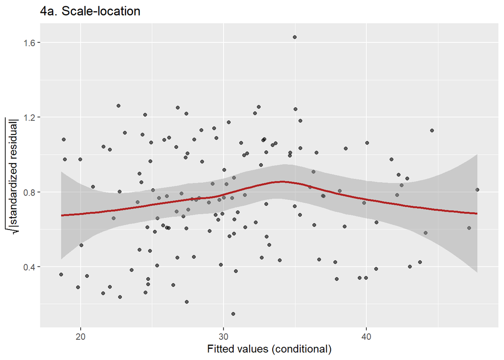

```r
# 4. Homoscedasticity (scale-location plot) -----------------------------------
# Plot sqrt(|standardized residual|) against fitted values. If the variance is
# constant, the smoothed line is roughly flat. A funnel or upward trend means
# the residual variance increases with the mean.
# Also check the variance by group, because the model assumes ONE sigma
# shared by both groups.
p_scale_loc <- ggplot(df_diag, aes(x = fit_cond, y = sqrt(abs(res_std)))) +
  geom_point(alpha = 0.6) +
  geom_smooth(method = "loess", formula = y ~ x, se = TRUE, colour = "firebrick") +
  labs(title = "4a. Scale-location",
       x = "Fitted values (conditional)",
       y = expression(sqrt("|standardized residual|")))
p_scale_loc
```

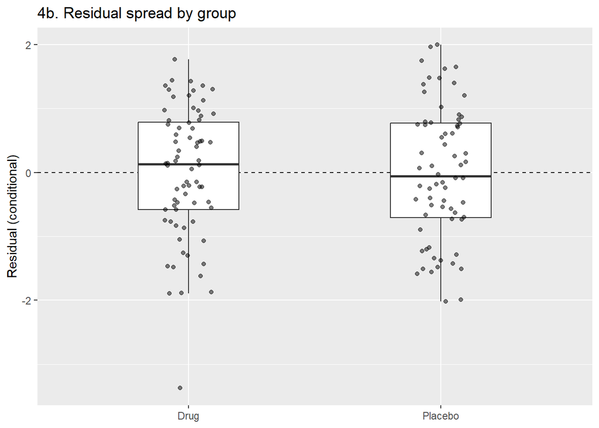

```r
p_var_group <- ggplot(df_diag, aes(x = group, y = res_cond)) +
  geom_hline(yintercept = 0, linetype = "dashed") +
  geom_boxplot(outlier.shape = NA, width = 0.4) +
  geom_jitter(width = 0.1, alpha = 0.5) +
  labs(title = "4b. Residual spread by group", x = NULL, y = "Residual (conditional)")
p_var_group
```

Next, we can check the normality of our residuals using a quantile-quantile (“QQ”) normal plot. In this plot we show the quantiles observed in the sample against the hypothetical quantiles we would observe if the data were perfectly normal.

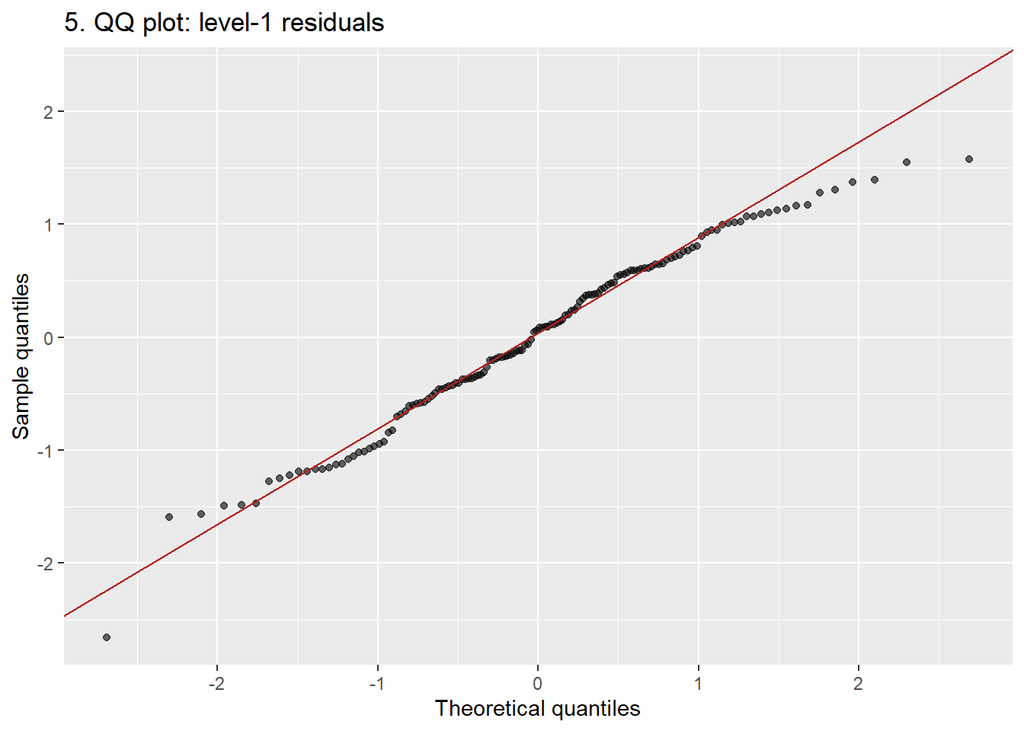

```r
# 5. Normality of level-1 residuals -------------------------------------------
# QQ plot of standardized conditional residuals. Points should lie close to
# the line. Heavy tails show up as an S shape, and skew as a curve.
# (In larger samples, mild non-normality here matters much less than errors
# in the mean structure.)
p_qq_resid <- ggplot(df_diag, aes(sample = res_std)) +
  stat_qq(alpha = 0.6) +
  stat_qq_line(colour = "firebrick") +
  labs(title = "5. QQ plot: level-1 residuals",
       x = "Theoretical quantiles", y = "Sample quantiles")
p_qq_resid
```

We can make equivalent plots of all of our random effects. The only notable difference will be that we should have fewer observations in these QQ plots. For instance, if I had 10 observations for 10 participants, my residual plot with have 100 data points, but a QQ plot of the random intercepts/slopes would only have 10 data points.

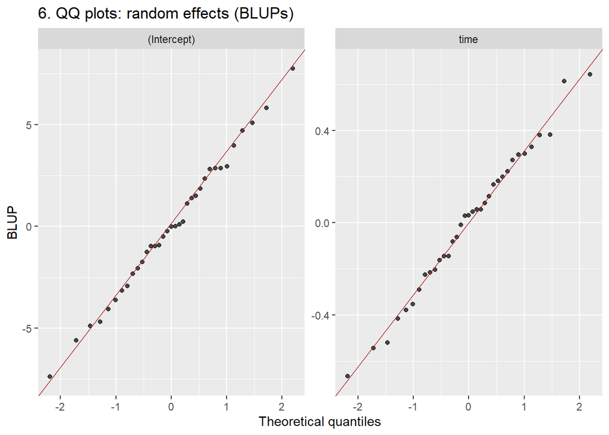

```r
# 6. Normality of the random effects ------------------------------------------
# One point per SUBJECT, so there are only n_sub points per panel. Expect
# some wobble. We are looking for gross departures or a single extreme
# subject.
# Caveat: BLUPs are shrunken toward 0 and can look "more normal" than the
# true random-effect distribution, so this check has limited power.
re_df <- ranef(mod_diag)$subID %>%
  as_tibble(rownames = "subID") %>%
  pivot_longer(-subID, names_to = "term", values_to = "blup")

p_qq_re <- ggplot(re_df, aes(sample = blup)) +
  stat_qq(alpha = 0.7) +
  stat_qq_line(colour = "firebrick") +
  facet_wrap(~ term, scales = "free_y") +
  labs(title = "6. QQ plots: random effects (BLUPs)",
       x = "Theoretical quantiles", y = "BLUP")
p_qq_re
```

Two things to keep in mind when checking the normality assumption:

1. This only applies to our “traditional” linear mixed effects model in which normality of the residuals and random-effects is assumed. For other models (e.g., ordinal models, logistic models), the normality assumption might only apply to the random effects or to neither. So, although we will probably be checking against normality most of the time, remember the key thing is to check the assumptions specific to your model. It is just that most of the time we are assuming normality.
2. Many learners want to reach for hypothesis tests as a way of getting a clear “go / no-go” decision about normality (e.g., Kruskil-Wallis or Shaprio-Wilk tests), but I would generally discourage this way of thinking about parametric assumptions. First, these tests are subject to many different vulnerabilities (e.g., low power an you miss non-normality or extreme sensitivity and you reject trivial non-normality in large samples). Second, violating normality happens on a continuum and so do its effects (i.e., our predictions get more wrong the less our assumptions hold, there is not a clear threshold at which we are right or wrong). Third, assuming that our other assumptions hold, linear mixed effect models are generally robust to violations of normality. So, unless you have extremely non-normal residuals - in which case you should probably reach for a different type of model - minor deviations from normality probably won’t appreciably affect your fixed effect estimates or statistical inferences.